# Homeworks 03

## Statistics comparisons

Next, we have a bunch of graphs to compare statistics between the observations and the replicated data.

The most simple one is the graph for comparing means:

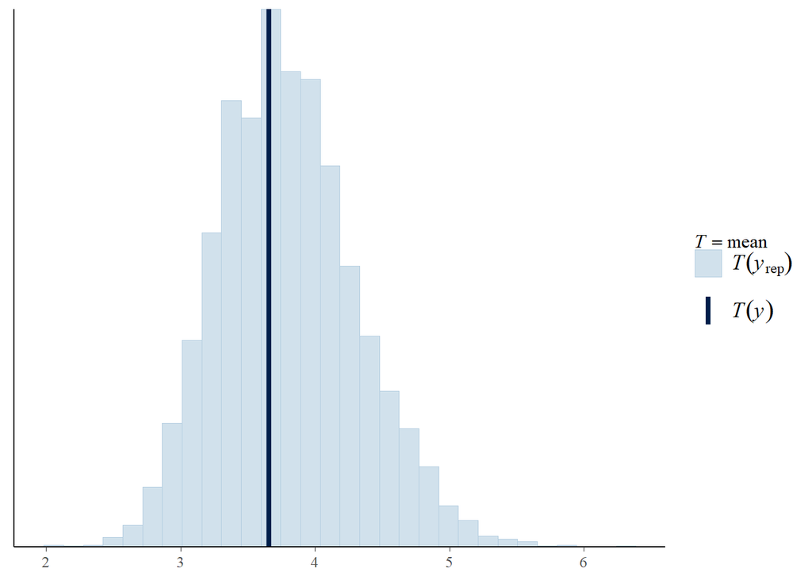

```r
ppc_stat(y, y_rep) #mean is default stat
```

What we can immediately notice from the graph is that the observations’ mean lies very close to the modal bin of the distribution of the replicated data means, another indication that, as far as this statistic is concerned, there’s a goodness of fit.

The analysis may be extended to another statistic. One of the stats that it’s very important to check when modelling count data is the proportion of zeros, which, in the Poisson model, was substantially different between original and replicated data. We pass the statistic to the `ppc_stat` method as an anonymous function:

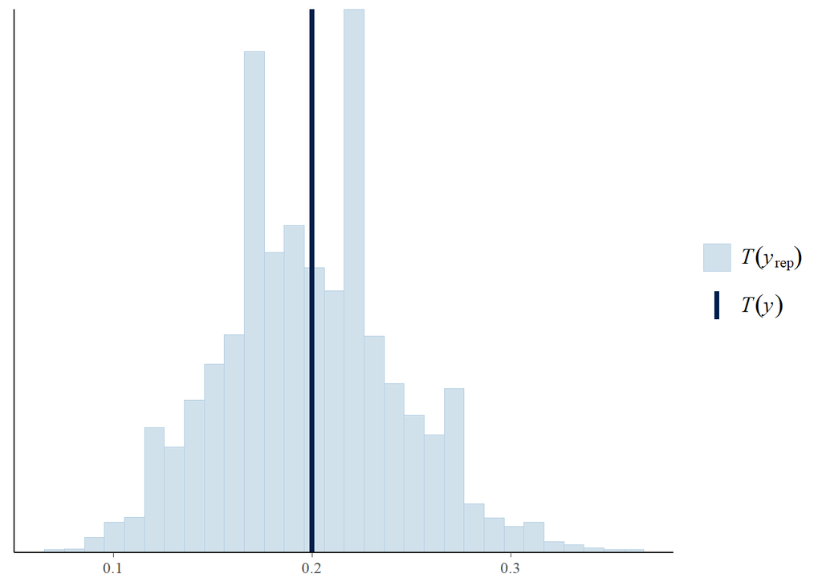

```r
ppc_stat(y, y_rep, stat = function(x) length(which(x==0))/length(x))
```

Though the generated quantities seem to follow a multimodal distribution, the observed data’s proportion of zeros seems to fit right in the median of it, which nonetheless has a high probability mass associated and, again, indicates an acceptable goodness of fit.

The same may be carried out for the subgroups of our model, the buildings. This for the mean:

```r
ppc_stat_grouped(
  y = stan_dat_hier$complaints,
  yrep = y_rep,
  group = pest_data$building_id,
  stat = 'mean',
  binwidth = 0.5
)
```

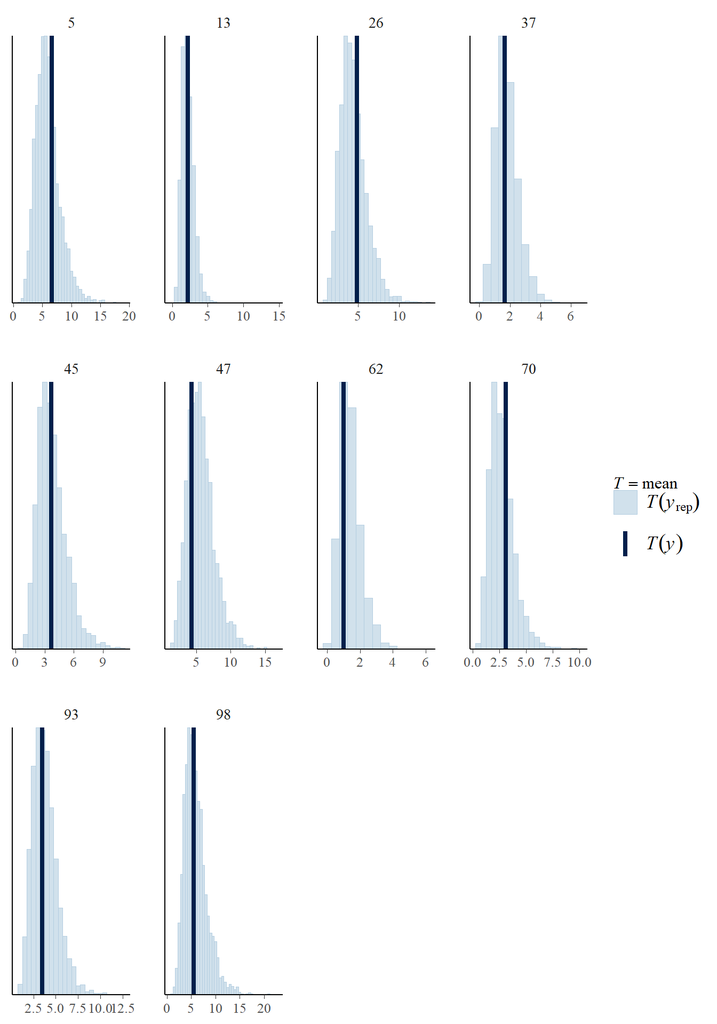

What we can notice is that the observed mean is always very close to the modal bin of the generated quantites’ means. This not only shows a general goodness of fit, but specifically indicates that the goodness of fit carries on to an increased granularity.

The following is the same analysis for the proportion of zeros:

```r
ppc_stat_grouped(
  y = stan_dat_hier$complaints,
  yrep = y_rep,
  group = pest_data$building_id,
  stat =  function(x) length(which(x==0))/length(x),
  binwidth = 0.04
)
```

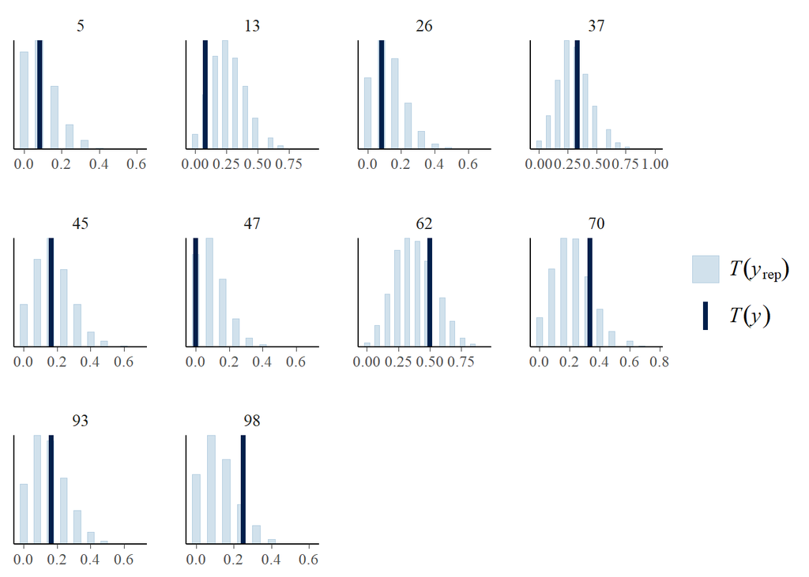